# AVALIAÇÃO MÉTODOS E TÉCNICAS DE PESQUISA QUANTITATIVA – 2015

Leonardo Martins

5 de janeiro de 2016

## Apresentação

O presente relatório foi elaborado utilizando o RStudio (0.99) e o pacote R versão 3.2.2 (2015). Todo o script em markdown utilizado para gerar o relatório, assim como imagens, banco de dados e outros arquivos complementares estão disponíveis para consulta no seguinte repositório do github http://github.com/leomartinsjf/m-quanti

O relatório final pode ser acessado através do link http://rpubs.com/leomartinsjf/m-quanti

## 1. Exercício

Um estudo visava avaliar questões de saúde mental entre professores universitários. Em um recorte do estudo, foram aplicadas duas escalas psicométricas, uma para Depressão e outra para Ansiedade, nos 16 professores do curso de Psicologia de uma universidade. Os pesquisadores pretendem saber se há uma relação entre estes dois construto, e se este comportamento é diferente entre o sexo dos professores. Responda as questões abaixo, sempre deixando clara a intepretação e justificativa dos resultados (40 pontos).

### *Tabela de Dados*

| ID | Depressão | Ansiedade | Sexo |
| --- | --- | --- | --- |
| 1 | 56 | 54 | M |
| 2 | 45 | 45 | M |
| 3 | 48 | 35 | F |
| 4 | 42 | 39 | M |
| 5 | 59 | 53 | M |
| 6 | 62 | 51 | F |
| 7 | 68 | 53 | M |
| 8 | 48 | 53 | M |
| 9 | 43 | 50 | M |
| 10 | 48 | 42 | M |
| 11 | 60 | 45 | M |
| 12 | 61 | 52 | M |
| 13 | 48 | 38 | F |
| 14 | 55 | 39 | M |
| 15 | 49 | 41 | F |
| 16 | 58 | 44 | F |

### a). Que tipos de variáveis foram utilizadas (natureza das variáveis)?

No presente estudo foram utilizadas variáveis quantitativas e qualitativas. As escalas de Depressão e Ansiedade podem ser consideradas como variáveis quantitativas intervalares, pois elas representam a mensuração de uma variável latente através de uma escala numérica que não possui zero absoluto. A variável Sexo é uma variável qualitativa nominal, pois determina duas categorias distintas e mutuamente excludentes, através das quais podemos contar a frequência de observações feita para cada categoria…

### b). Monte uma tabela com as análises descritivas do banco de dados total. Faça também uma análise descritiva das escalas dentro de cada grupo de Sexo. Não se esqueçam de: Porcentagens, Medidas de tendência central (média e/ou mediana), Desvio padrão, Intervalo Interquartil etc…

A seguir, a fim de preparar as estatísticas descritivas, foi elaborado uma rotina no software R que está descrita abaixo e que é complementada por uma tabela e conjunto de gráficos que sintetizam os resultados.

#### **Preparação para as análises - Script R**

Importando a tabela de dados em CSV

```r
base <- read.csv("~/m-quanti/Trabalho Laisa/base.csv", sep=";")
#Geração do objeto "base" a partir dos dados importados de um arquivo em CSV
```

Carregando os pacotes que serão utilizados nas análises

```r
require(psych)
require(gridExtra)
require(ggplot2)
require(car)
```

#### **a.1. Análise Descritiva Geral**

Obtenção das principais estatísticas descritivas das variáveis do total da amostra

```r
summary(base)
```

```
##        ID          depressao       ansiedade     sexo
##  Min.   : 1.00   Min.   :42.00   Min.   :35.00   F: 5
##  1st Qu.: 4.75   1st Qu.:48.00   1st Qu.:40.50   M:11
##  Median : 8.50   Median :52.00   Median :45.00
##  Mean   : 8.50   Mean   :53.12   Mean   :45.88
##  3rd Qu.:12.25   3rd Qu.:59.25   3rd Qu.:52.25
##  Max.   :16.00   Max.   :68.00   Max.   :54.00
```

Complementação das estatísticas descritivas para as variáveis quantitativas utilizando a função “describe” do pacote “psych”

```r
describe(base$depressao)
```

```
##   vars  n  mean   sd median trimmed  mad min max range skew kurtosis   se
## 1    1 16 53.12 7.72     52   52.86 9.64  42  68    26 0.22     -1.3 1.93
```

```r
describe(base$ansiedade)
```

```
##   vars  n  mean   sd median trimmed mad min max range  skew kurtosis  se
## 1    1 16 45.88 6.42     45   46.07 8.9  35  54    19 -0.13    -1.62 1.6
```

#### **a.2. Análise Descritiva das Escalas por Sexo**

Usando a função “tapply” e “describeBy” para repetir as análises descritivas anteriores das escalas agora por sexo para:

**a.2.1 Estatisticas Descritivas - Escala Depressão**

```r
tapply(base$depressao, base$sexo, summary)
```

```
## $F
##    Min. 1st Qu.  Median    Mean 3rd Qu.    Max.
##      48      48      49      53      58      62
##
## $M
##    Min. 1st Qu.  Median    Mean 3rd Qu.    Max.
##   42.00   46.50   55.00   53.18   59.50   68.00
```

```r
describeBy(base$depressao, base$sexo)
```

```
## group: F
##   vars n mean   sd median trimmed  mad min max range skew kurtosis   se
## 1    1 5   53 6.56     49      53 1.48  48  62    14 0.38    -2.06 2.93
## --------------------------------------------------------
## group: M
##   vars  n  mean   sd median trimmed   mad min max range skew kurtosis   se
## 1    1 11 53.18 8.49     55   52.78 10.38  42  68    26 0.15    -1.47 2.56
```

**a.2.2 Gráficos Escala de Depressão**

```r
#Histograma de Frequencias*
d0<-ggplot(base, aes(depressao)) + theme(legend.position = "none") + geom_histogram(colour = "black", fill = "white") + labs(x = "Escores", y = "Frequência")

#Histograma de Densidade com Curva Normal Teórica*
d1<- ggplot(base, aes(depressao)) + theme(legend.position = "none") + geom_histogram(aes(y = ..density..), colour = "black", fill = "white") + labs(x = "Escores", y = "Densidade") + stat_function(fun = dnorm, args = list(mean = mean(base$depressao, na.rm = TRUE), sd = sd(base$depressao, na.rm = TRUE)), colour = "black", size = 1)

#Q-Q plot*
d2<- ggplot(base, aes(sample = depressao)) + stat_qq(colour = "black", fill = "white") + labs(x = "QQ - Distribuição Normal Teórica", y = "Escore Depressão") + theme(legend.position = "none")

#Boxplot*
d3<- ggplot(base, aes(x=factor(0), depressao)) + geom_boxplot(colour = "black", fill = "white") + labs(x = "Box-Plot", y = "Escores Depressão") + theme(legend.position = "none", axis.ticks.x=element_blank(), axis.text.x=element_blank())
```

**a.3.1 Estatisticas Descritivas - Escala Ansiedade**

```r
tapply(base$ansiedade, base$sexo, summary)
```

```
## $F
##    Min. 1st Qu.  Median    Mean 3rd Qu.    Max.
##    35.0    38.0    41.0    41.8    44.0    51.0
##
## $M
##    Min. 1st Qu.  Median    Mean 3rd Qu.    Max.
##   39.00   43.50   50.00   47.73   53.00   54.00
```

```r
describeBy(base$ansiedade, base$sexo)
```

```
## group: F
##   vars n mean   sd median trimmed  mad min max range skew kurtosis   se
## 1    1 5 41.8 6.14     41    41.8 4.45  35  51    16 0.36    -1.66 2.75
## --------------------------------------------------------
## group: M
##   vars  n  mean   sd median trimmed  mad min max range  skew kurtosis   se
## 1    1 11 47.73 5.88     50      48 5.93  39  54    15 -0.35    -1.71 1.77
```

**a.3.2 Gráficos - Escalas Ansiedade**

```r
#Histograma de Frequencias*
d0<-ggplot(base, aes(ansiedade)) + theme(legend.position = "none") + geom_histogram(colour = "black", fill = "white") + labs(x = "Escores", y = "Frequência")

#Histograma de Densidade com Curva Normal Teórica*
d1<- ggplot(base, aes(ansiedade)) + theme(legend.position = "none") + geom_histogram(aes(y = ..density..), colour = "black", fill = "white") + labs(x = "Escores", y = "Densidade") + stat_function(fun = dnorm, args = list(mean = mean(base$ansiedade, na.rm = TRUE), sd = sd(base$ansiedade, na.rm = TRUE)), colour = "black", size = 1)

#Q-Q plot*
d2<- ggplot(base, aes(sample = ansiedade)) + stat_qq(colour = "black", fill = "white") + labs(x = "QQ - Distribuição Normal Teórica", y = "Escore Ansiedade") + theme(legend.position = "none")

#Boxplot*
d3<- ggplot(base, aes(x=factor(0), ansiedade)) + geom_boxplot(colour = "black", fill = "white") + labs(x = "Box-Plot", y = "Escores Ansiedade") + theme(legend.position = "none", axis.ticks.x=element_blank(), axis.text.x=element_blank())
```

#### **Apresentação dos Resultados Sintetizados das Análises Descritivas**

**Sexo**

A amostra estudada foi composta por 16 pessoas, sendo 11 do sexo masculino (68,75%) e o restante do sexo feminino.

**a) Escala de Depressão**

**a.1) Mulheres**

**a.2) Homens**

Os resultados descritos acima podem ser observados na **Tabela 1**.

**a.3) Distribuição dos Escores**

A distribuição dos escores totais na amostra, considerando o tamanho pequeno do n foi feita por inspeção visual e não parecem não apontar para que os dados sejam provenientes de uma distribuição normal, apesar de serem aproximadamente simétricos, apresentam importante desvio com relação à Kurtosis. Como não existe uma informação prévia acerca desta distribuição na população, a partir de uma postura conservadora, aceitamos a hipótese nula que afirma que esta distribuição não é proveniente de uma população normal.

**Tabela 1. Análise descritiva dos níveis de Depressão na amostra total e por sexo**

[output not shown]

[figure not shown]

```r
#Plotar gráficos Quadro 1
grid.arrange(d0, d1, d2, d3, ncol=2, top="Quadro1 - Análise Descritiva Gráfica - Escala Depressão")
```

### **b) Escala de Ansiedade**

Os escores da escala de ansiedade variaram 19 unidades, com valor mínimo de 35 e máximo de 54 pontos. A pontuação mediana (P50) na escala de ansiedade foi igual a 45 e a pontuação média foi de 45,9 pontos (DP= 6,42), apontando para uma leve assimetria negativa (Skewness = -0,13 se= 1,60). Os primeiros 25% da amostra (Q1) tiveram até 40,5 pontos na escala e os 25% escores mais altos (Q3) obtiveram 52,2 pontos ou mais.

**b.1) Mulheres**

**b.2) Homens**

Os resultados descritos podem ser observados na **Tabela 2**.

**b.3) Distribuição dos Escores**

A análise da distribuição dos escores totais na amostra, considerando o tamanho pequeno do “n” foi feita também por inspeção visual e não apresenta indícios fortes de que os dados sejam provenientes de uma distribuição normal, apresentando uma assimétrica negativa ainda que leve e importante desvio com relação à Kurtosis. Como não existe uma informação prévia acerca desta distribuição na população, a partir de uma postura conservadora, aceitamos a hipótese nula que afirma que esta distribuição não é proveniente de uma população normal.

Os gráficos utilizados para inspeção visual podem ser observados no **Figura 2**.

**Tabela 2. Análise descritiva dos níveis de Ansiedade na amostra total e por sexo**

[output not shown]

**Figura 2 - Análise Descritiva Gráfica - Escala Ansiedade**

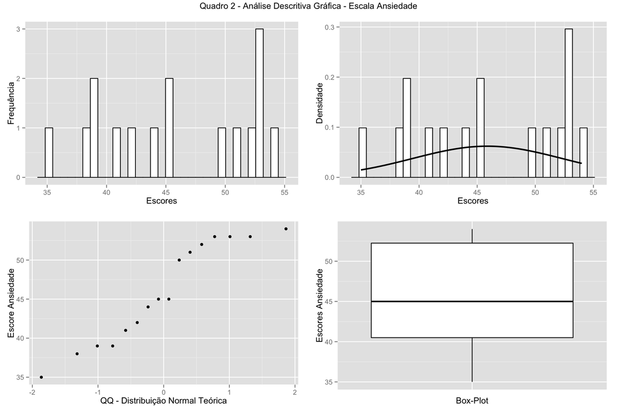

```r
#Plotar Gráficos Quadro 2
grid.arrange(d0, d1, d2, d3, ncol=2, top="Quadro 2 - Análise Descritiva Gráfica - Escala Ansiedade")
```

## c). Existe diferença entre Homens e Mulheres quanto à Depressão e Ansiedade? Formule as hipóteses Nula e Alternativa e aplique os testes adequados para respondê-las.

#### **Hipóteses - Diferença entre Homens e Mulheres em Relação à Depressão**

**Hipótese Nula (H0) :**

Não existe diferença estatisticamente significativa entre homens e mulheres em relação os níveis de depressão mensurados pela escala utilizada.

**Hipótese Alternativa (H1):**

Existe diferença estatisticamente significativa entre homens e mulheres em relação aos níveis de depressão mensurados pela escala utilizada.

**Análise de Dados**

Considerando a análise exploratória dos dados realizada anteriormente, assume-se aqui que as distribuições dos níveis de depressão entre homens e mulheres não é proveniente de uma distribuição normal. Logo, considerando o tamanho de “n” pequeno e o desbalanceamento da amostra em relação ao sexo, optou-se por utilizar o teste de Wilcoxon para 2 amostras independentes, assumindo um nível de significância de 5% para rejeitar a hipótese nula.

**Resultados**

```r
# Duas amostras independentes -  Teste de Wilcoxon/Mann-Whitney U
wilcox.test(base$depressao~base$sexo)
```

```
##
##  Wilcoxon rank sum test with continuity correction
##
## data:  base$depressao by base$sexo
## W = 30, p-value = 0.8194
## alternative hypothesis: true location shift is not equal to 0
```

Comparando a distribuições dos escores de depressão entre homens e mulheres é possível observar que os homens apresentaram um valor de escore mediano maior (Md= 55) do que as mulheres (Md= 49). É possível observar através do boxplot (**Figura 3**) que apesar desta diferença em relação à mediana a distribuição dos escores das mulheres está sobreposta à dos homens, indicando uma possível ausência de diferença entre os grupos que é apoiada pelo resultado do teste de Wilcoxon que nos leva a não rejeitar a hipótese nula (W=30, p=0,819).

**Figura 3 - Boxplot Escores de Depressão por Sexo**

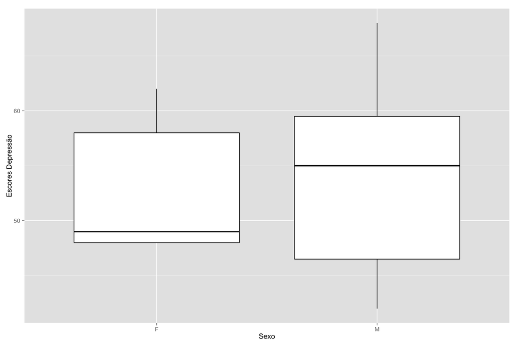

```r
ggplot(base, aes(sexo, depressao)) + geom_boxplot(colour = "black", fill = "white") + labs(x = "Sexo", y = "Escores Depressão") + theme(legend.position = "none")
```

#### **Hipóteses - Diferença entre Homens e Mulheres em Relação à Ansiedade**

*Hipótese Nula (H0) :*

Não existe diferença estatisticamente significativa entre homens e mulheres em relação os níveis de ansiedade mensurados pela escala utilizada.

*Hipótese Alternativa (H1):*

Existe diferença estatisticamente significativa entre homens e mulheres em relação aos níveis de ansiedade mensurados pela escala utilizada.

**Análise de Dados**

Considerando a análise exploratória dos dados realizada anteriormente, assume-se aqui que a distribuição dos níveis de ansiedade entre homens e mulheres não é proveniente de uma distribuição normal. Logo, considerando o tamanho de “n” pequeno e o desbalanceamento da amostra em relação à sexo optou-se também por utilizar o teste de Wilcoxon para 2 amostras independentes, assumindo um nível de significância de 5% para rejeitar a hipótese nula.

**Resultados**

```r
# Duas amostras independentes -  Teste de Wilcoxon/Mann-Whitney U
wilcox.test(base$ansiedade~base$sexo)
```

```
##
##  Wilcoxon rank sum test with continuity correction
##
## data:  base$ansiedade by base$sexo
## W = 11, p-value = 0.06866
## alternative hypothesis: true location shift is not equal to 0
```

**Figura 4 - Boxplot Escores de Ansiedade por Sexo**

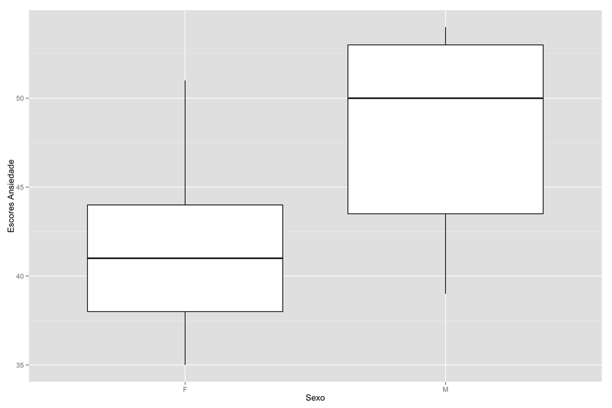

```r
ggplot(base, aes(sexo, ansiedade)) + geom_boxplot(colour = "black", fill = "white") + labs(x = "Sexo", y = "Escores Ansiedade") + theme(legend.position = "none")
```

### d) Depressão e Ansiedade são correlacionadas (amostra geral)?

**Hipótese Nula (H0):**

Não existe correlação estatisticamente significativa entre os escores de Ansiedade e Depressão na amostra geral.

**Hipótese Alternativa (H1):**

Existe algum grau de correlação estatisticamente significativa entre Ansiedade de Depressão na amostra geral.

**Análise de Dados**

Observando as características de ambas as distribuições já citadas anteriormente optou-se por utilizar o teste não paramétrico da correlação bi-variada de Spearman-Brown para testar a hipótese nula a um nível de significância de 5%.

**Resultados**

```r
cor.test(base$depressao, base$ansiedade, method="spearman")
```

```
##
##  Spearman's rank correlation rho
##
## data:  base$depressao and base$ansiedade
## S = 349.11, p-value = 0.05595
## alternative hypothesis: true rho is not equal to 0
## sample estimates:
##       rho
## 0.4866093
```

A inspeção visual da associação entre os escores das variáveis depressão e ansiedade parece apontar para uma correlação positiva moderada/fraca como apontada pelo rho=0,49 de Spearman-Brown e que pode ser observado em maiores detalhes na (**Figura 5**). Contudo, partindo do nível de significância adotado em comparação com a significância encontrada (p=0,056) optamos por aceitar a hipótese nula, indicado que a associação visível pode ter sido fruto do acaso. Cabe destacar, entretanto, que em uma amostra maior poderíamos potencialmente indicar que a associação entre as variáveis é estatisticamente significativa, assumindo aqui o indicativo que o resultado foi próximo do nível de significância adotado e que em amostras pequenas corremos um maior risco de cometar um erro do Tipo II, aceitando a hipótese nula quando esta é falsa - exigindo, tão logo, cautela na tomada de decisão em relação aos resultados encontrados aqui.

**Figura 5 - Gráfico de Dispersão - Escalas de Ansiedade e Depressão (com reta de regressão paramétrica e não paramétrica).**

[figure not shown]

```r
scatterplot(depressao ~ ansiedade, data=base, xlab="Escore Depressão", ylab="Escore Ansiedade", main= "Figura 5 - Correlação entre Ansiedade e Depressão")
```

### Exercício 2

A tabela 1 abaixo foi retirada do artigo *“Risks of anemia in infants according to dietary iron density and weight gain rate”*, publicado na revista **Preventive Medicine**. Neste estudo, os pesquisadores queriam saber quais eram os fatores de risco para Anemia, classificada como “Sim” (tem anemia) e “Não” (não tem anemia). Foram testadas inúmeras variáveis como possíveis fatores de risco associados a anemia, dentre elas as variáveis sociodemográficas que estão apresentadas na tabela. As variáveis são “Ocupação da Mãe” (Trabalhadora ou Dona de Casa), “Número de Moradores no Domicílio” (3 ou menos e Mais do que 3), “Número de crianças menores de 5 anos” (2 ou mais e 1) e “Gênero” (Feminino e Masculino). Responda às questões abaixo, sempre justificando sua interpretação (30 pontos).

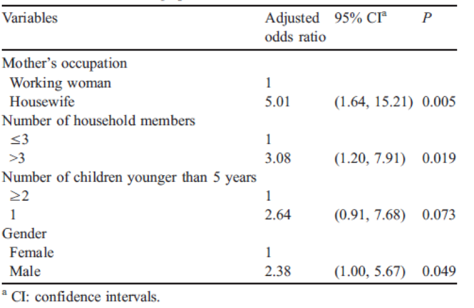

**a. Descreva os maiores fatores de risco para a Anemia deixando clara sua interpretação dos resultados.**

**b. Discuta o risco encontrado para “Número de crianças menores de 5 anos” quanto à sua estimativa (odds ratio) e significância estatística (valor de p). Você acha que é um fator de risco importante?**

A melhor análise desta variável pode ser feita através da observação do intervalo de confiança do OR estimado ou invés de sua estimativa pontual. O limite inferior do IC foi menor que 1 (OR IC inf = 0,91), indicando que ter em casa 1 (uma) “criança mais jovem do que 5 anos”" poderia ser na população um fator de proteção. Simultaneamente o limite superior do IC (OR IC sup = 7,68) indicou que as crianças nesta condição poderiam ter mais de 7 vezes mais chances de terem anemia.

Dessa forma, a estimativa pontual do OR=2,64 não nos permite tomar uma decisão que considere assumir que possuir 1 (uma) “criança menor do que 5 anos” aumenta a chance de esta possuir anemia em relação às casas que possuem 2 (duas) ou mais. Dado que o intervalo de confiança foi definido como de 95%, o valor de p>0,05 acaba por apontar para a tendência da estimativa incluir um valor de razão de chances igual um (OR=1) e valores que estão acima e abaixo de um (1), impedindo a tomada de decisão em favor da interpretação da estimativa pontual do OR como um fator de risco ou proteção - à exemplo do caso acima.

### **Referências

Allaire, JJ Jeffrey Horner, Vicent Marti and Natacha Porte (2015). markdown: ‘Markdown’ Rendering for R. R package version 0.7.7. http://CRAN.R-project.org/package=markdown

Baptiste, A. (2015). gridExtra: Miscellaneous Functions for “Grid” Graphics. R package version 2.0.0. http://CRAN.R-project.org/package=gridExtra

Fox, J & Weisberg, S. (2011). An {R} Companion to Applied Regression, Second Edition. Thousand Oaks CA: Sage. URL: http://socserv.socsci.mcmaster.ca/jfox/Books/Companion

R Core Team (2015). R: A language and environment for statistical computing. R Foundation for Statistical Computing, Vienna, Austria. URL https://www.R-project.org/.

Revelle, W. (2015) psych: Procedures for Personality and Psychological Research, Northwestern University, Evanston, Illinois, USA, http://CRAN.R-project.org/package=psych Version = 1.5.8.

Wickham, H. (2009) ggplot2: elegant graphics for data analysis. Springer New York.